# CR_issue_0701

# Prepare package, data and functions

```r
library(dplyr)
library(readxl)
library(readr)
library(knitr)
library(haven)
library(visdat)
library(sjstats)
library(openxlsx)
library(stargazer)
library(broom)
library(ggplot2)
library(sjPlot)
library(stringr)
library(fda)
library(caret)
library(future)
library(purrr)
library(furrr)
library(here)
library(svrep)
library(patchwork)


######## Load Functions ########
source("src/00_sim_data_function.R")
source("src/01_sim_functions.R")
source("src/revised_func.R")
source('src/99_visualization_func.R')
print('Functions have been loaded')
```

```
[1] "Functions have been loaded"
```

# Estimate True Population Effects

## Regression Setting

Assume complete NHANES dataset as the sup-population.
$$y_i(s) = \beta_0(s) + X_i \beta_1(s) + \epsilon_i(s), \quad s = 1, 2, \ldots, 1440$$

- $y_i(s)$: PA monitoring data for individual i
- $X_i$: Scalar covariate, and we consider age here
- $\beta_0(s)$: Time-varying regression coefficients
- $\epsilon_i(s) \sim N(0, \sigma^2(s))$

## Estimate and visualize true effects

```r
## Load NHANES Data
nhanes_df = readRDS('data/pa_df_persub.rds') |>
  dplyr::rename(Age = age_in_years_at_screening) |>
  dplyr::rename(weight = full_sample_2_year_mec_exam_weight)
min_columns <- nhanes_df %>%
  dplyr::select(starts_with("min")) %>% names()

## Point-wise effects: Regression at each time point
# results.lr <- map_dfr(min_columns, ~ {
#   model <- lm(reformulate("Age", response = .x), data = nhanes_df)
#   tidy(model) %>%
#     filter(term == "Age") %>%
#     mutate(Variable = .x, Intercept = coef(model)[1], Beta = estimate) %>%
#     select(Variable, Intercept, Beta)
# })
# write_rds(results.lr, 'data/nhanes_true_effect_lr.rds')

results.lr = read_rds('data/nhanes_true_effect_lr.rds')

## Visualization
true_effect_raw = plot_pw_effects(results.lr)
```

## Smoothed True Estimates

### Use GCV to select spar and use cubic spline

```r
intercept_smooth <- smooth.spline(results.lr$Intercept)
beta_smooth <- smooth.spline(results.lr$Beta)
  # Here, we use GCV to select spar (cubic smoothing spline)
  # ‘generalized’ cross-validation (GCV) when cv = FALSE
results.lr$Intercept_smoothed <- predict(intercept_smooth)$y
results.lr$Beta_smoothed <- predict(beta_smooth)$y
```

### Use B-spline to smooth

#### Choose the number of basis

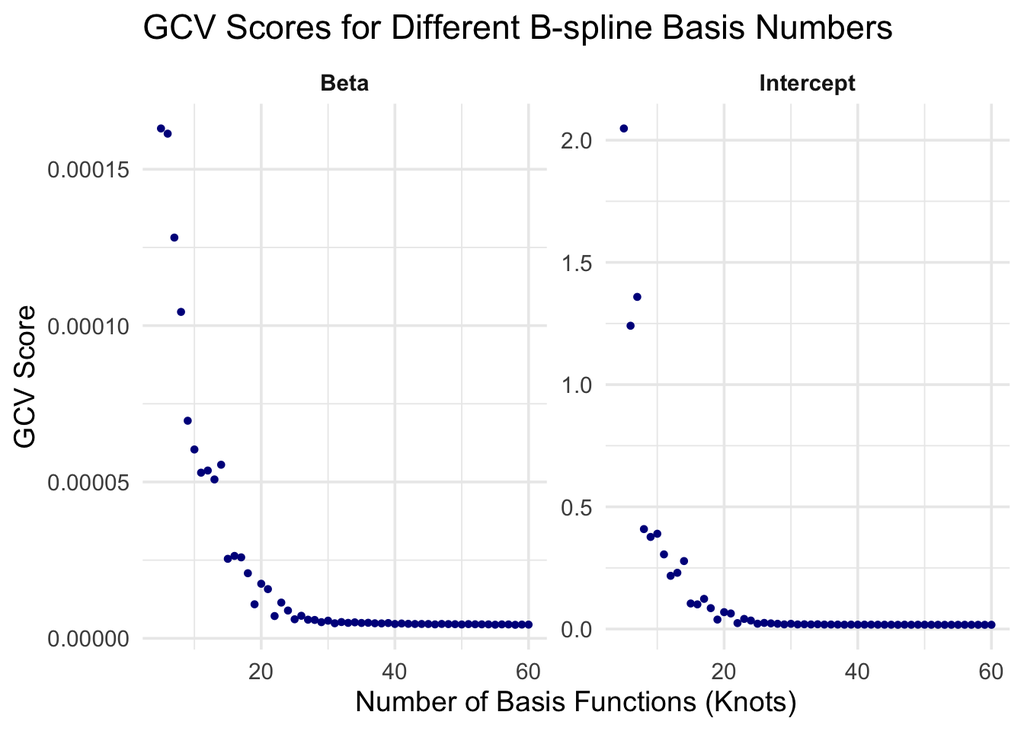

```r
nbasis_range <- 5:60

# GCV for Intercept
gcv_intercept <- sapply(nbasis_range, function(k) {
  basis <- create.bspline.basis(c(1, 1440), nbasis = k)
  fdParobj <- fdPar(basis, Lfdobj = 2, lambda = 1e-2)
  smooth <- smooth.basis(argvals = 1:1440, y = results.lr$Intercept, fdParobj)
  return(smooth$gcv)
})

# GCV for Beta
gcv_beta <- sapply(nbasis_range, function(k) {
  basis <- create.bspline.basis(c(1, 1440), nbasis = k)
  fdParobj <- fdPar(basis, Lfdobj = 2, lambda = 1e-2)
  smooth <- smooth.basis(argvals = 1:1440, y = results.lr$Beta, fdParobj)
  return(smooth$gcv)
})

gcv_df <- tibble(
  nbasis = rep(nbasis_range, 2),
  GCV = c(gcv_beta, gcv_intercept),
  Type = rep(c("Beta", "Intercept"), each = length(nbasis_range))
)

ggplot(gcv_df, aes(x = nbasis, y = GCV)) +
  geom_point(size = 1.2, color = "darkblue") +
  facet_wrap(~ Type, scales = "free_y") +
  labs(title = "GCV Scores for Different B-spline Basis Numbers",
       x = "Number of Basis Functions (Knots)",
       y = "GCV Score") +
  theme_minimal(base_size = 14) +
  theme(strip.text = element_text(face = "bold"))
```

#### Visualization of basis

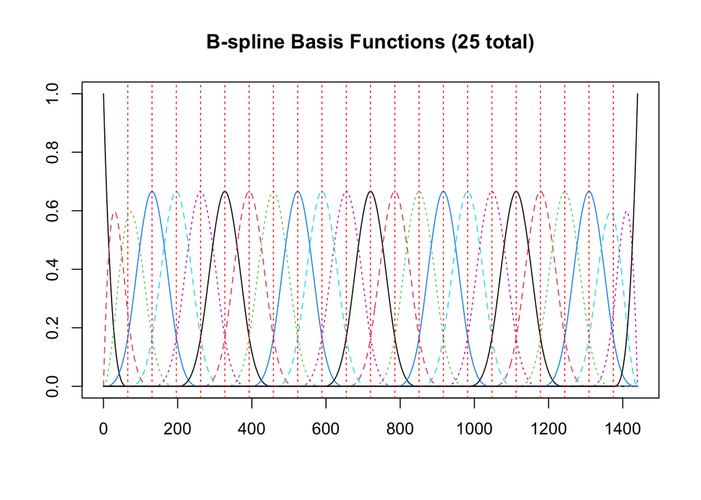

```r
library(fda)
basis <- create.bspline.basis(rangeval = c(0, 1440), nbasis = 25)
plot(basis, main = "B-spline Basis Functions (25 total)")
```

#### Generate smoothed estimates

```r
fdParobj <- fdPar(basis, Lfdobj = 2, lambda = 1e-2)
smooth.fd <- smooth.basis(argvals = c(1:1440), y = results.lr$Beta, fdParobj)$fd
results.lr$Beta_smoothed_bspline = eval.fd(c(1:1440), smooth.fd)

smooth.fd <- smooth.basis(argvals = c(1:1440), y = results.lr$Intercept, fdParobj)$fd
results.lr$Intercept_smoothed_bspline = eval.fd(c(1:1440), smooth.fd)
```

### Visualization of smoothed estimates (basis n=25)

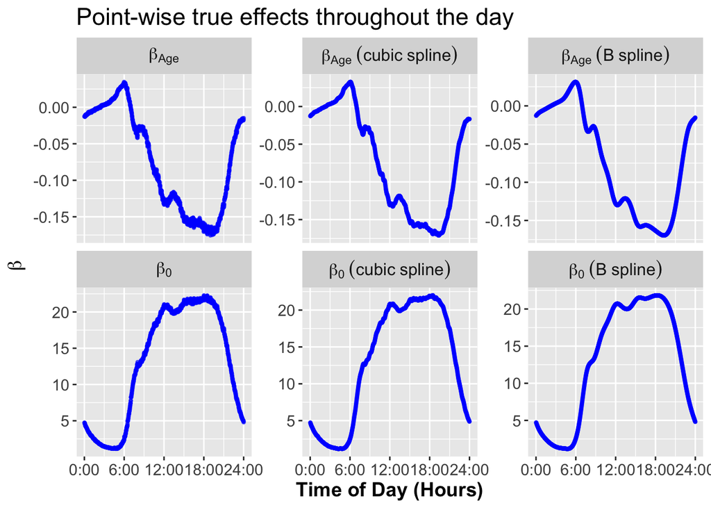

```r
facet_labels = c(
  "Beta" = "beta[Age]",
  "Intercept" = "beta[0]",
  "Beta_smoothed" = "beta[Age]~(cubic~spline)",
  "Intercept_smoothed" = "beta[0]~(cubic~spline)",
  "Beta_smoothed_bspline" = "beta[Age]~(B~spline)",
  "Intercept_smoothed_bspline" = "beta[0]~(B~spline)"
)

type_vars = c(
  "Beta",
  "Intercept",
  "Beta_smoothed",
  "Intercept_smoothed",
  "Beta_smoothed_bspline",
  "Intercept_smoothed_bspline"
)

plot_pw_effects(results.lr,
                facet_labels = facet_labels,
                type_vars = type_vars)
```

### Export Smoothed Estimates

```r
results.lr.smoothed.bspline = results.lr |>
  dplyr::select(Variable, Intercept_smoothed_bspline, Beta_smoothed_bspline) |>
  dplyr::rename(Intercept = Intercept_smoothed_bspline, Beta = Beta_smoothed_bspline)

# write_rds(results.lr.smoothed.bspline,
#           'data/nhanes_true_effect_lr_smoothed_bspline.rds')
```

### Extra example

#### increase smoothness of true estimates (basis n=10)

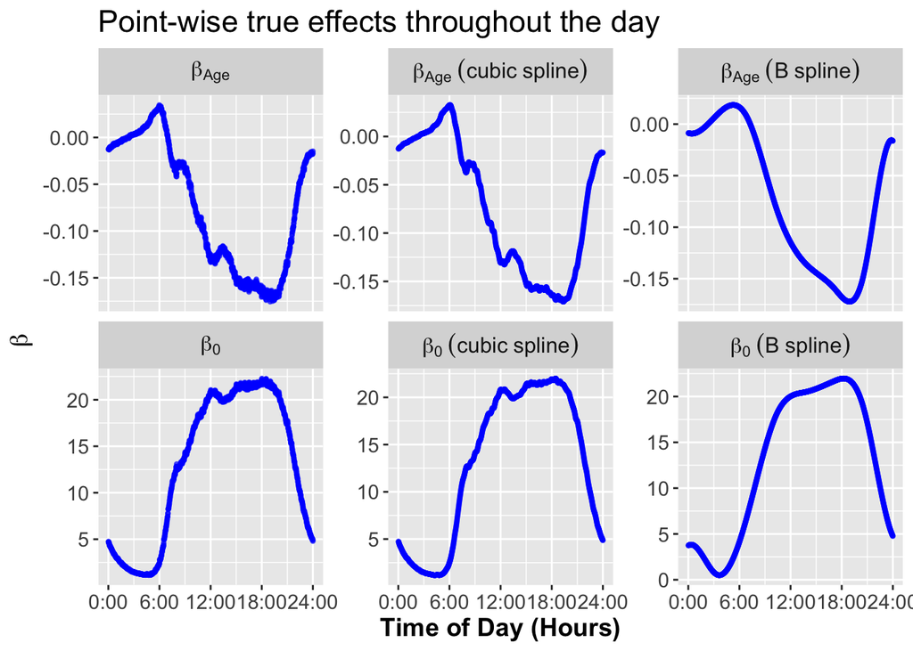

```r
basis <- create.bspline.basis(rangeval = c(0, 1440), nbasis = 10)
fdParobj <- fdPar(basis, Lfdobj = 2, lambda = 1e-2)
smooth.fd <- smooth.basis(argvals = c(1:1440), y = results.lr$Beta, fdParobj)$fd
results.lr$Beta_smoothed_bspline = eval.fd(c(1:1440), smooth.fd)

smooth.fd <- smooth.basis(argvals = c(1:1440), y = results.lr$Intercept, fdParobj)$fd
results.lr$Intercept_smoothed_bspline = eval.fd(c(1:1440), smooth.fd)
facet_labels = c(
  "Beta" = "beta[Age]",
  "Intercept" = "beta[0]",
  "Beta_smoothed" = "beta[Age]~(cubic~spline)",
  "Intercept_smoothed" = "beta[0]~(cubic~spline)",
  "Beta_smoothed_bspline" = "beta[Age]~(B~spline)",
  "Intercept_smoothed_bspline" = "beta[0]~(B~spline)"
)

type_vars = c(
  "Beta",
  "Intercept",
  "Beta_smoothed",
  "Intercept_smoothed",
  "Beta_smoothed_bspline",
  "Intercept_smoothed_bspline"
)

plot_pw_effects(results.lr,
                facet_labels = facet_labels,
                type_vars = type_vars)
```

```r
results.lr.smoothed.bspline.n10 = results.lr |>
  dplyr::select(Variable, Intercept_smoothed_bspline, Beta_smoothed_bspline) |>
  dplyr::rename(Intercept = Intercept_smoothed_bspline, Beta = Beta_smoothed_bspline)

# write_rds(results.lr.smoothed.bspline.n10,
#           'data/nhanes_true_effect_lr_smoothed_bspline_n10.rds')
```

# Non-informative sampling

1. Generate strata selection probabilities ($H=30$) from Dirichlet distribution
2. Sample $N=\{15\}$ strata in the simulation
3. For each strata $h$ in the selected strata:
   - Standardize Age into mean=0 and SD=1
   - Calculate inclusion probabilities $p_i = exp(Age_{i}/2)$
   - Normalize: $p_{i'} = \frac{p_i}{\sum_{i \in h}p_i}$
   - Adjust by expected number of individuals sampled $p_{i''} = min(p_{i'} * I_n * 2, 1)$
   - Obtain sample using binomial sampling

## Factors associated with joint-wise CR

```r
## example A: default setting
exampleA_summary = visualize_from_folder(folder = 'results/NI/',
                                         file_pattern = "sim_noOrigial_survey_L150_.*\\.rds",
                                         L = 150)

## case 01: make true estimates smoother
case01_summary = visualize_from_folder(folder = 'results/NI/case01_L150/',
                                       file_pattern = '',
                                       L = 150)

## case 02: make true estimates smoother + increase Boot Number
case02_summary = visualize_from_folder(folder = 'results/NI/case02_L150/',
                                       file_pattern = 'case.*',
                                       L = 150)

## case 03: increase smooth level (basis number: 25->10)
case03_summary = visualize_from_folder(folder = 'results/NI/case03_L150/',
                                       file_pattern = '',
                                       L = 150)

## case 04: increase number of knots used in fPCA (34->120)
case04_summary = visualize_from_folder(folder = 'results/NI/case04_L150/',
                                       file_pattern = '',
                                       L = 150)

## case 05: increase scaling factor (1.2->1.3)
case05_summary = visualize_from_folder(folder = 'results/NI/case05_L150/',
                                       file_pattern = '',
                                       L = 150)

## case 06: not smooth
case06_summary = visualize_from_folder(folder = 'results/NI/case06_L150/',
                                       file_pattern = '',
                                       L = 150)

## case 07: not smooth + run 500 times
case07_summary = visualize_from_folder(folder = 'results/NI/case07_L150/',
                                       file_pattern = '',
                                       L = 150)

## case 08: not smooth (compare RWYB and weighted)
case08_summary = visualize_from_folder(folder = 'results/NI/case08_L150/',
                                       file_pattern = '',
                                       L = 150)

## case 09: smooth for CI, but not smooth for variance
case09_summary = visualize_from_folder(folder = 'results/NI/case09_L150/',
                                       file_pattern = '',
                                       L = 150)

## case 10: not smooth + keep scaling factor=1.2
case10_summary = visualize_from_folder(folder = 'results/NI/case10_L150/',
                                       file_pattern = '',
                                       L = 150)

## case 11: smooth for CI, not smooth for variance, but increase knot number
case11_summary = visualize_from_folder(folder = 'results/NI/case11_L150/',
                                       file_pattern = '',
                                       L = 150)

## case 12: smooth for variance, but not smooth for CI, but increase knot number
case12_summary = visualize_from_folder(folder = 'results/NI/case12_L150/',
                                       file_pattern = '',
                                       L = 150)
```

### Results

#### Default

**Default Parameters:**

True Estimate: Cubic-spline Length of functional domain: L = 150  
Bootstrap Number: B = 100  
Knots for smoothing bootstrapped estimates: L = 50  
Smooth bootstrapped estimates and use smoothed values to conduct CMA:  
smooth_for_ci = TRUE smooth_for_variance = TRUE  
Knots for conducting fPCA: L/2 = 75

```r
exampleA_summary
```

Summary Statistics

| boot_type | var | MISE | mean_joint_se | mean_pw_se | cover_joint_ratio | cover_pw_ratio |
| --- | --- | --- | --- | --- | --- | --- |
| Preston | Beta | 0.0000 | 0.0090 | 0.0031 | 0.900 | 0.9610 |
| Preston | Intercept | 0.0281 | 0.4931 | 0.1728 | 0.865 | 0.9490 |
| none | Beta | 0.0001 | 0.0027 | 0.0009 | 0.000 | 0.0005 |
| none | Intercept | 0.2284 | 0.1711 | 0.0534 | 0.000 | 0.0171 |
| weighted | Beta | 0.0000 | 0.0032 | 0.0010 | 0.055 | 0.4981 |
| weighted | Intercept | 0.0281 | 0.1799 | 0.0559 | 0.065 | 0.5078 |

- L=150, ‘Preston’ performs better, but jw-coverage ratio lower than expectations (0.9 vs 0.95).

#### Smooth true estimates (basis n=25)

```r
case01_summary
```

Summary Statistics

| boot_type | var | MISE | mean_joint_se | mean_pw_se | cover_joint_ratio | cover_pw_ratio |
| --- | --- | --- | --- | --- | --- | --- |
| Preston | Beta | 0.0000 | 0.0090 | 0.0031 | 0.920 | 0.9603 |
| Preston | Intercept | 0.0285 | 0.4931 | 0.1728 | 0.890 | 0.9486 |
| Rao-Wu-Yue-Beaumont | Beta | 0.0000 | 0.0090 | 0.0032 | 0.920 | 0.9600 |
| Rao-Wu-Yue-Beaumont | Intercept | 0.0285 | 0.4952 | 0.1734 | 0.895 | 0.9479 |

- Use B-splines to smooth true estimates, and we use 25 basis

#### Smooth true estimates (basis n=10)

```r
case03_summary
```

Summary Statistics

| boot_type | var | MISE | mean_joint_se | mean_pw_se | cover_joint_ratio | cover_pw_ratio |
| --- | --- | --- | --- | --- | --- | --- |
| Preston | Beta | 0.0000 | 0.0090 | 0.0031 | 0.815 | 0.9248 |
| Preston | Intercept | 0.1749 | 0.4928 | 0.1723 | 0.000 | 0.5132 |
| Rao-Wu-Yue-Beaumont | Beta | 0.0000 | 0.0090 | 0.0031 | 0.805 | 0.9255 |
| Rao-Wu-Yue-Beaumont | Intercept | 0.1749 | 0.4957 | 0.1735 | 0.005 | 0.5166 |

#### Increase knot number when conduct fPCA

Smoothed true estimates: basis number n=25  
knot number for FPCA: 75->120  
smooth_for_ci = TRUE  
smooth_for_variance = TRUE

```r
case04_summary
```

Summary Statistics

| boot_type | var | MISE | mean_joint_se | mean_pw_se | cover_joint_ratio | cover_pw_ratio |
| --- | --- | --- | --- | --- | --- | --- |
| Preston | Beta | 0.0000 | 0.0091 | 0.0031 | 0.930 | 0.9603 |
| Preston | Intercept | 0.0285 | 0.4984 | 0.1728 | 0.890 | 0.9486 |
| Rao-Wu-Yue-Beaumont | Beta | 0.0000 | 0.0091 | 0.0032 | 0.925 | 0.9600 |
| Rao-Wu-Yue-Beaumont | Intercept | 0.0285 | 0.5005 | 0.1734 | 0.900 | 0.9479 |

#### Increase scaling factor

Smoothed true estimates: basis number n=25  
knot number for FPCA: 75->120  
scaling factor: 1.20->1.3  
smooth_for_ci = TRUE  
smooth_for_variance = TRUE

```r
case05_summary
```

Summary Statistics

| boot_type | var | MISE | mean_joint_se | mean_pw_se | cover_joint_ratio | cover_pw_ratio |
| --- | --- | --- | --- | --- | --- | --- |
| Preston | Beta | 0.0000 | 0.0094 | 0.0033 | 0.950 | 0.9672 |
| Preston | Intercept | 0.0285 | 0.5188 | 0.1798 | 0.905 | 0.9564 |
| Rao-Wu-Yue-Beaumont | Beta | 0.0000 | 0.0095 | 0.0033 | 0.940 | 0.9666 |
| Rao-Wu-Yue-Beaumont | Intercept | 0.0285 | 0.5210 | 0.1805 | 0.920 | 0.9550 |

#### not smooth for CI and for variance

Smoothed true estimates: basis number n=25  
knot number for FPCA: 75->120  
scaling factor: 1.20->1.3  
smooth_for_ci = FALSE  
smooth_for_variance = FALSE

```r
case08_summary
```

Summary Statistics

| boot_type | var | MISE | mean_joint_se | mean_pw_se | cover_joint_ratio | cover_pw_ratio |
| --- | --- | --- | --- | --- | --- | --- |
| Preston | Beta | 0.0000 | 0.0114 | 0.0035 | 0.970 | 0.9773 |
| Preston | Intercept | 0.0285 | 0.6340 | 0.1924 | 0.950 | 0.9662 |
| Rao-Wu-Yue-Beaumont | Beta | 0.0000 | 0.0115 | 0.0035 | 0.980 | 0.9777 |
| Rao-Wu-Yue-Beaumont | Intercept | 0.0285 | 0.6386 | 0.1935 | 0.945 | 0.9677 |
| weighted | Beta | 0.0000 | 0.0044 | 0.0036 | 0.200 | 0.9877 |
| weighted | Intercept | 0.0285 | 0.2479 | 0.1983 | 0.310 | 0.9797 |

#### not smooth for CI and for variance, keep scaling factor = 1.2

Smoothed true estimates: basis number n=25  
knot number for FPCA: 75->120  
scaling factor: 1.20  
smooth_for_ci = FALSE  
smooth_for_variance = FALSE

```r
case10_summary
```

Summary Statistics

| boot_type | var | MISE | mean_joint_se | mean_pw_se | cover_joint_ratio | cover_pw_ratio |
| --- | --- | --- | --- | --- | --- | --- |
| Preston | Beta | 0.0000 | 0.0110 | 0.0034 | 0.945 | 0.9714 |
| Preston | Intercept | 0.0285 | 0.6091 | 0.1848 | 0.945 | 0.9592 |
| Rao-Wu-Yue-Beaumont | Beta | 0.0000 | 0.0110 | 0.0034 | 0.955 | 0.9726 |
| Rao-Wu-Yue-Beaumont | Intercept | 0.0285 | 0.6135 | 0.1859 | 0.940 | 0.9613 |
| weighted | Beta | 0.0000 | 0.0042 | 0.0034 | 0.170 | 0.9835 |
| weighted | Intercept | 0.0285 | 0.2382 | 0.1906 | 0.280 | 0.9746 |

#### smooth for CI, but not smooth for variance, keep scaling factor = 1.2

Smoothed true estimates: basis number n=25  
knot number for FPCA: 75->120  
scaling factor: 1.20  
smooth_for_ci = TRUE  
smooth_for_variance = FALSE

```r
case11_summary
```

Summary Statistics

| boot_type | var | MISE | mean_joint_se | mean_pw_se | cover_joint_ratio | cover_pw_ratio |
| --- | --- | --- | --- | --- | --- | --- |
| Preston | Beta | 0.0000 | 0.0098 | 0.0034 | 0.910 | 0.9714 |
| Preston | Intercept | 0.0285 | 0.5363 | 0.1848 | 0.855 | 0.9592 |
| Rao-Wu-Yue-Beaumont | Beta | 0.0000 | 0.0098 | 0.0034 | 0.905 | 0.9726 |
| Rao-Wu-Yue-Beaumont | Intercept | 0.0285 | 0.5387 | 0.1859 | 0.875 | 0.9613 |
| weighted | Beta | 0.0000 | 0.0110 | 0.0034 | 0.990 | 0.9835 |
| weighted | Intercept | 0.0285 | 0.6156 | 0.1906 | 0.985 | 0.9746 |

#### smooth for variance, but not smooth for CI

```r
case12_summary
```

Summary Statistics

| boot_type | var | MISE | mean_joint_se | mean_pw_se | cover_joint_ratio | cover_pw_ratio |
| --- | --- | --- | --- | --- | --- | --- |
| Preston | Beta | 0.0000 | 0.0102 | 0.0031 | 0.965 | 0.9600 |
| Preston | Intercept | 0.0285 | 0.5674 | 0.1723 | 0.945 | 0.9484 |
| Rao-Wu-Yue-Beaumont | Beta | 0.0000 | 0.0103 | 0.0031 | 0.965 | 0.9607 |
| Rao-Wu-Yue-Beaumont | Intercept | 0.0285 | 0.5721 | 0.1735 | 0.950 | 0.9499 |
| weighted | Beta | 0.0000 | 0.0012 | 0.0010 | 0.000 | 0.4972 |
| weighted | Intercept | 0.0285 | 0.0703 | 0.0560 | 0.000 | 0.5063 |

## RWYB vs Weighted

[figure not shown]

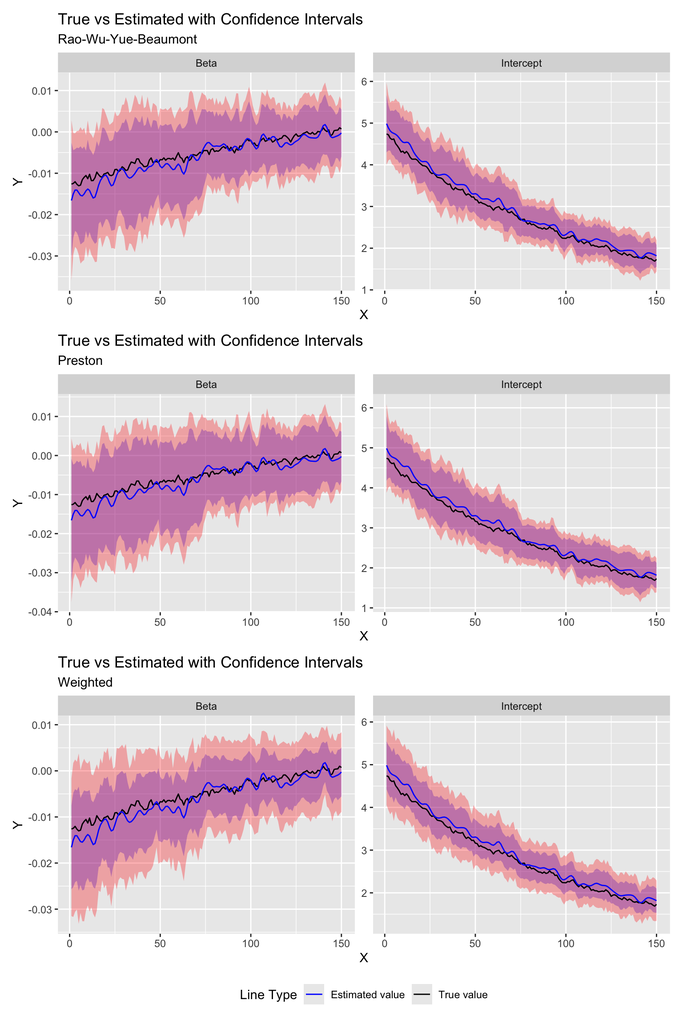

```r
var_name = c('Intercept', 'Beta')
L = 150
testL = 1:L
dat = read_rds('tmp_result/NI_visualization_case09_L150.rds')

plot = list()
plot[['RWYB']] = visualize_notCover(
  beta_true = t(results.lr |> dplyr::select(-Variable))[, testL],
  mod_output = dat[[1]],
  L_domain = testL,
  subtitle = 'Rao-Wu-Yue-Beaumont'
)
plot[['Preston']] = visualize_notCover(
  beta_true = t(results.lr |> dplyr::select(-Variable))[, testL],
  mod_output = dat[[2]],
  L_domain = testL,
  subtitle = 'Preston'
)
plot[['Weighted']] = visualize_notCover(
  beta_true = t(results.lr |> dplyr::select(-Variable))[, testL],
  mod_output = dat[[3]],
  L_domain = testL,
  subtitle = 'Weighted'
)

wrap_plots(plot, nrow = 3, ncol = 1) +
  plot_layout(guides = "collect") &
  theme(legend.position = "bottom")
```